# Multi-view Layout

Matthew Heino

2025-01-22

# Data Description

- Variable 1: **State** - holds the name of the state where the data was collected
- Variable 2: **Year** - the year in which the data was collected
- Variable 3: **CrimeRate** - the crime rate

The data needed to be prepared before it could be processed. The steps are the following:

- Step 1: Read in the data from the xlsx file (“Sampledata2.xlsx”)
- Step 2: View the contents of the data frame
- Step 3: Create the colors for the graphs
- Step 4: Create the histogram
- Step 5: Create the scatter plot
- Step 6: Grouped boxplot
- Step 7: Create the multi-view plot of the histogram, scatterplot, and the boxplot

Loading the appropriate packages will also be necessary.

**Note:** The classic theme has not been used.

### Load the required packages

The required packages:

- tidyverse - to provide plotting functions and other
- colorspace - provide the color functions that are required to create colors for the graphs
- GridExtra - for creating the arrangement of the plots
- readxl - provides the ability to read the Excel file

The working directory was also set.

```r
if(!require(tidyverse)) {install.packages('tidyverse')}; require(tidyverse)
if(!require(colorspace)) {install.packages('colorspace')}; require(colorspace)
if(!require(gridExtra)) {install.packages('gridExtra')}; require(gridExtra)

library(tidyverse)
library(readxl)
library(gridExtra)

#Set the working directory
setwd(dirname(rstudioapi::getSourceEditorContext()$path))
```

### 1) Read in the data from the xlsx file

Read in the data from the xlsx file with the file name “Sampledata2.xlsx”. Show the first six rows of the data frame and the last six rows to show what is in the data set. This was see what is in the data.

```r
crime_rates_df = readxl::read_xlsx('Sampledata2.xlsx')
```

### 2) Inspect the data

View the composition of the data and see what columns are included.

```r
head(crime_rates_df)
```

```
## # A tibble: 6 × 3
##   State    Year CrimeRate
##   <chr>   <dbl>     <dbl>
## 1 Alabama  2007      448
## 2 Alabama  2008      453.
## 3 Alabama  2009      450.
## 4 Alabama  2010      378.
## 5 Alabama  2011      420.
## 6 Alabama  2012      450.
```

```r
tail(crime_rates_df)
```

```
## # A tibble: 6 × 3
##   State    Year CrimeRate
##   <chr>   <dbl>     <dbl>
## 1 Wyoming  2013      208.
## 2 Wyoming  2014      196.
## 3 Wyoming  2015      222.
## 4 Wyoming  2016      244.
## 5 Wyoming  2017      235.
## 6 Wyoming  2018      212.
```

The data set is composed of the following columns:

- State - holds the name of the state where the data was collected
- Year - the year in which the data was collected
- CrimeRate - the crime rate

### 3) Create the color vectors for the graphs

```r
# Create the first color vector
n_col = length(unique(crime_rates_df$Year))
col1 = colorspace::diverge_hcl(n_col)
```

### 4) Create the histogram

All the years that were in the data set are included in the figure below. The histogram was be created using the CrimeRate and the Year columns from the data set.

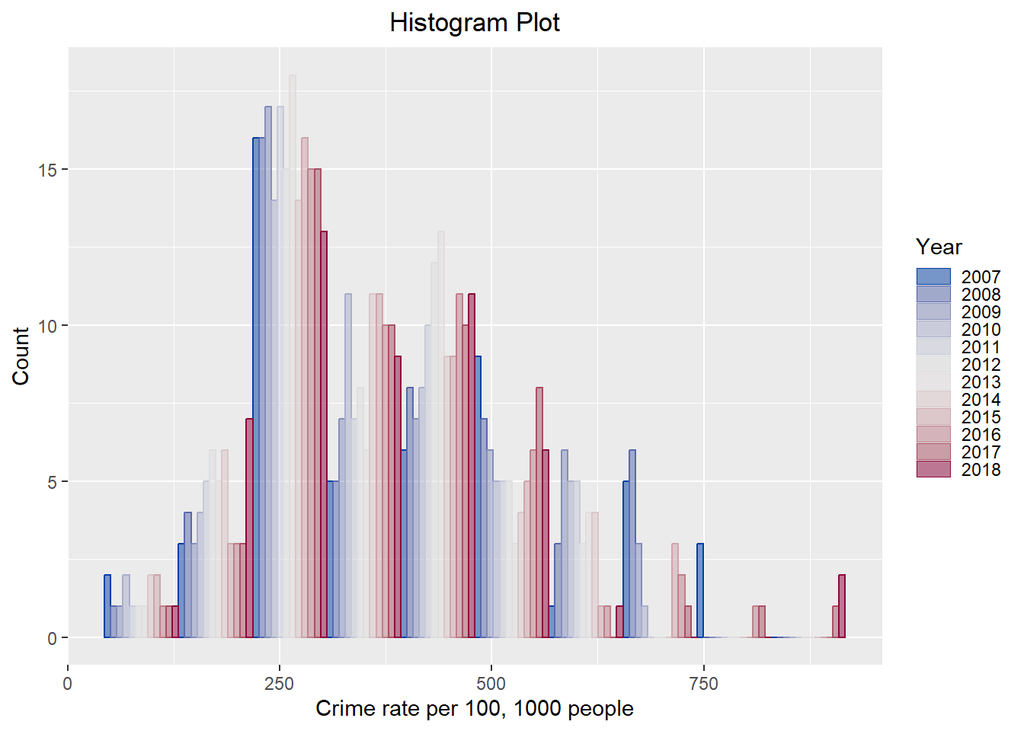

```r
hist_plt <- ggplot(crime_rates_df,aes(x=CrimeRate, color=as.factor(Year), fill=as.factor(Year))) +
  geom_histogram(position = "dodge", alpha=0.5, bins=10) +
  scale_color_manual(values=col1) +
  scale_fill_manual(values=col1, name="Year") +
  labs(title="Crime Rate Histogram Plots", x="Crime rate per 100, 1000 people",
       y="Count", color="Year") +
  theme(plot.title=element_text(hjust=0.5),legend.key.height = unit(.10, 'cm'))+
  ggtitle("Histogram Plot")

hist_plt
```

### 5) Create the scatter plot

This plot is a line and point plot. The data for this plot comes from creating a anew column the contains the mean of the crime rate. The plot runs from the year 2007 to 2018.

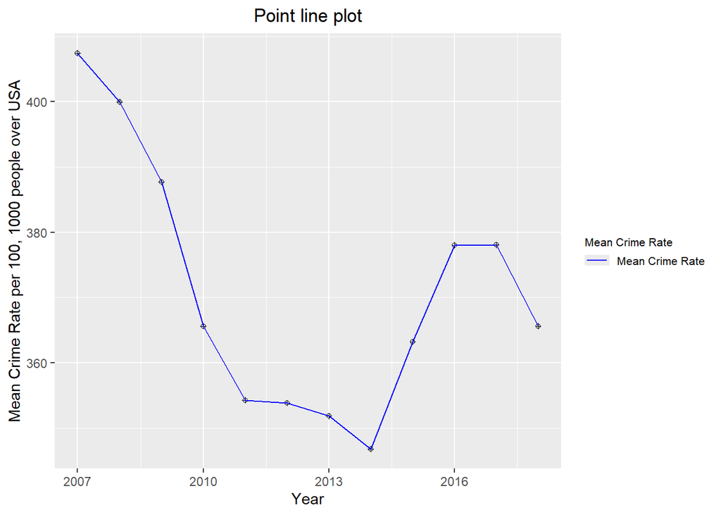

```r
crime_rates_df_new <- crime_rates_df %>%
  group_by(Year) %>%
  summarize(mean_rate=mean(CrimeRate),max_rate=max(CrimeRate), min_rate=min(CrimeRate))

line_plt <- ggplot(crime_rates_df_new, aes(x = Year, y = mean_rate, lty="Mean Crime Rate" )) +
  scale_linetype("Mean Crime Rate") +
  geom_point(color='black', shape=10) +
  geom_line(color="blue") +
  labs(title="Crime Rate Histogram Plots", x="Year",
       y="Mean Crime Rate per 100, 1000 people over USA") +
  theme(plot.title=element_text(hjust=0.5), legend.text = element_text(size =8),
        legend.title = element_text(size = 8), legend.key.height = unit(.10, 'cm')) +
  ggtitle("Point line plot")

line_plt
```

### 6) Grouped boxplot

This is a grouped box plot that shows the the distribution of the data across the years that are found in the data set.

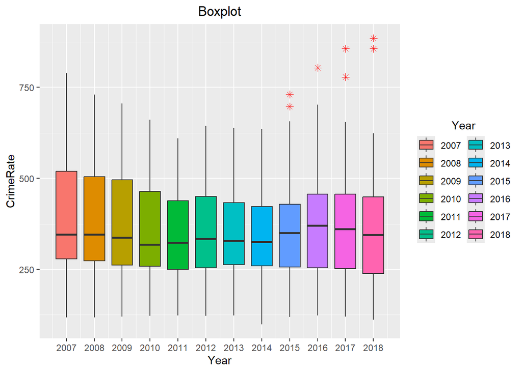

```r
min <- min(crime_rates_df$Year)
max <- max(crime_rates_df$Year)

box_plt <- ggplot(crime_rates_df) +
  geom_boxplot(aes(x=Year, y= CrimeRate, fill=as.factor(Year), ),
               outlier.colour="red", outlier.shape=8, outlier.size=2) +
  guides(fill=guide_legend(title = 'Year',title.position = "top", nrow=6)) +
  theme(legend.position = "right", legend.title.align=0.5) +
  scale_x_continuous(breaks=seq(min, max, by=1)) +
  theme(plot.title=element_text(hjust=0.5)) +
  ggtitle("Boxplot")

box_plt
```

### 7) Create the multi-view plot of the histogram, scatterplot, and the boxplot

This layout uses the grid.arrange() function to arrange the the plots in an order that is similar to the solution. The **lay** variable contains a matrix to position the graphs.

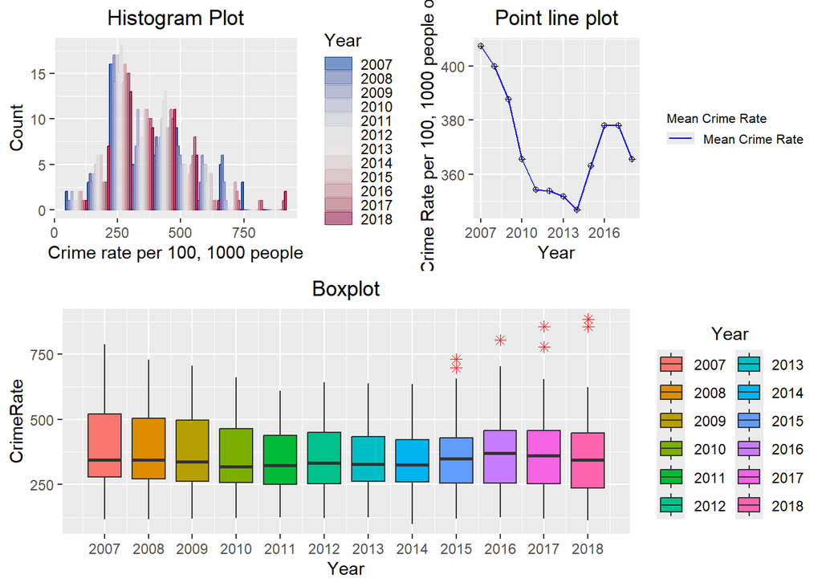

```r
lay <- rbind(c(1, 1, 1, 2, 2, 2),
             c(1, 1, 1, 2, 2, 2),
             c(1, 1, 1, 2, 2, 2),
             c(1, 1, 1, 2, 2, 2),
             c(1, 1, 1, 2, 2, 2),
             c(1, 1, 1, 2, 2, 2),
             c(3, 3, 3, 3, 3, 3),
             c(3, 3, 3, 3, 3, 3),
             c(3, 3, 3, 3, 3, 3),
             c(3, 3, 3, 3, 3, 3),
             c(3, 3, 3, 3, 3, 3),
             c(3, 3, 3, 3, 3, 3),
             c(3, 3, 3, 3, 3, 3))

grid_plt <- grid.arrange(hist_plt, line_plt, box_plt, layout_matrix=lay)
```